# Non-additive genetic effects induce novel phenotypic distributions in male mating traits of F1 hybrids

## General strength of d<sub>mismatch</sub>

Estimated mean d<sub>mismatch</sub> across all studies by phylogenetic random model (using `MCMCglmm` function).

The model included following Random effects estimates:

- `Study.ID`: Primary studies
- `sp1.name`: Phylogeny of parental species
- `Cross.ID`: Parental strain used in the crossing. Discriminate intraspecific populations
- `Hybrid`: Crossing direction
- `SE.units`: Sampling variance of effect size

```r
#++++++++++++++++++++++++++++++++++#
print("Phylogenetic tree for mcmcglmm")
```

```
[1] "Phylogenetic tree for mcmcglmm"
```

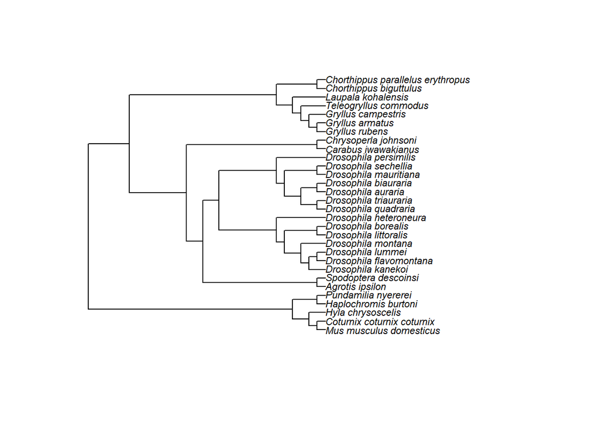

```r
#++++++++++++++++++++++++++++++++++#

# compute branch lengths of tree
phylo_branch <- read.tree(file = "../data/phylo.novelty.tre") %>%
  compute.brlen(method = "Grafen", power = 1)
plot.phylo(phylo_branch, cex = 0.7)
```

```r
# # saving phylogeneic matrix
# phylo_cor <- vcv(phylo_branch, cor = T)
#
# # generating inverse phylogenetic matrix for MCMCglmm
# phylo_branch$node.label <- NULL
# phylo_MCMC <- MCMCglmm::inverseA(phylo_branch, nodes = "ALL", scale = TRUE)$Ainv

# phylmix <-MCMCglmm(
#   fixed = Mismatch ~  1,
#   # idh(SE):units | weight by SE of effect size
#   random = ~ Study.ID + sp1.name + Cross.ID + Hybrid,
#   verbose = FALSE,
#   ginverse = list(sp1.name = phylo_MCMC),
#   nitt = 60000,  # Increase the number of iterations, default is 13000
#   burnin = 5000,  # Increase the number of burnin, default is 3000
#   data = dat
# )
# saveRDS(phylmix, file = "../Analysis/mismatch.obj")

phylmix <- readRDS("../Analysis/mismatch.obj")

#+++++++++++++++++++++++++++#
# Fixed effects output
#+++++++++++++++++++++++++++#
get_fixed.MCMCglmm(summary(phylmix)$solutions) %>%
  dplyr::select("Factors", "Estimates", "95% credible interval", "P") %>%
  kable("html", digits = 3, caption = "Fixed effects estimates") %>%
  kable_styling("striped", position = "left")
```

Fixed effects estimates

| Factors | Estimates | 95% credible interval | P |
| --- | --- | --- | --- |
| (Intercept) | 4.41 | -3.05 – 10.29 | 0.166 |

```r
#+++++++++++++++++++++++++++#
# Random effects output
#+++++++++++++++++++++++++++#
# transformation for varaince
get_random.MCMCglmm(summary(phylmix$VCV)) %>%
  kable("html", digits = 2, caption = "Random effects estimates") %>%
  kable_styling("striped", position = "left")
```

Random effects estimates

| Random effects | Estimates | 95% credible interval |
| --- | --- | --- |
| Study.ID | 1.18 | 0–11.21 |
| sp1.name | 8.31 | 0–70.99 |
| Cross.ID | 42.58 | 13.07–101.37 |
| Hybrid | 28.14 | 0–61.22 |
| units | 2801.56 | 2740.38–2865.59 |

Even data included quite large d<sub>mismatch</sub>, overall it did not differ from 0. Yet, the estimate (β = 4.41, CI = -3.05 – 10.29) is still much larger than previously reported mean d<sub>mismatch</sub> 0.6 (Thompson et al. 2021). This is presumably because novelty in phenotypic means, which should increase d<sub>mismatch</sub>, is much more frequent in our data compared to [Thompson et al.](https://www.biorxiv.org/content/10.1101/818658v1.full#disp-formula-1) (2021).

## Factors affecting d<sub>mismatch</sub>

We asked if any species-level moderators (Genetic divergence between parents, `Genet.divergence`; Viability of reciprocal cross, `Reciprocal`; Heterogametic sex, `Hetero.sex`; Parents’ distribution overlap, `Distribution`) influence d<sub>mismatch</sub> values by phylogenetic random model. Random effects were identical as [above] (## General pattern of mismatch d<sub>mismatch</sub>).

```r
dat3 <- dat %>%
  drop_na(Genet.divergence, Reciprocal, Hetero.sex, Distribution)

# phylmix <-MCMCglmm(
#   fixed = Mismatch ~  Genet.divergence + Reciprocal + Hetero.sex + Distribution,
#   # idh(SE):units | weight by SE of effect size
#   random = ~ Study.ID + sp1.name + Cross.ID + Hybrid,
#   verbose = FALSE,
#   ginverse = list(sp1.name = phylo_MCMC),
#   nitt = 60000,  # Increase the number of iterations, default is 13000
#   burnin = 5000,  # Increase the number of burnin, default is 3000
#   data = dat3
# )
# saveRDS(phylmix, file = "../Analysis/mismatch.reg.obj")

phylmix <- readRDS("../Analysis/mismatch.reg.obj")

#+++++++++++++++++++++++++++#
# Fixed effects output
#+++++++++++++++++++++++++++#
get_fixed.MCMCglmm(summary(phylmix)$solutions)  %>%
  dplyr::select("Factors", "Estimates", "95% credible interval", "P") %>%
  kable("html", digits = 3, caption = "Fixed effects estimates") %>%
  kable_styling("striped", position = "left")
```

Fixed effects estimates

| Factors | Estimates | 95% credible interval | P |
| --- | --- | --- | --- |
| (Intercept) | -1.72 | -27.5 – 23.1 | 0.903 |
| Genet.divergence | -1.38 | -11.56 – 8.6 | 0.788 |
| ReciprocalViable | -8.27 | -39.1 – 19.25 | 0.562 |
| Hetero.sexMale | 11.74 | -24.15 – 50.92 | 0.512 |
| DistributionAllopatry | -2.59 | -31.14 – 27.31 | 0.847 |

```r
#+++++++++++++++++++++++++++#
# Random effects output
#+++++++++++++++++++++++++++#
# transformation for varaince
get_random.MCMCglmm(summary(phylmix$VCV)) %>%
    kable("html", digits = 2, caption = "Random effects estimates") %>%
    kable_styling("striped", position = "left")
```

Random effects estimates

[output not shown]

None of species level moderators did not influence d<sub>mismatch</sub>, as [Thompson et al.](https://www.biorxiv.org/content/10.1101/818658v1.full#disp-formula-1)(2021) showed.

# Meta-analysis for phenotypic variation (using lnVR)

## Allign parental species according to phenotypic variation

```r
#+++++++++++++++++++++++++++++++++++++++++++++++++#
# sp1 >= sp2 in phenotypic variation
#+++++++++++++++++++++++++++++++++++++++++++++++++#
# extract
sp1sp2.var <- original.dat %>%
  filter(SD.sp1 >= SD.sp2) # filtering according to CV of parentals
# change column name from sp1 or sp2 -> spL or spS
names(sp1sp2.var) <- gsub("1", "L", names(sp1sp2.var))
names(sp1sp2.var) <- gsub("2", "S", names(sp1sp2.var))

#+++++++++++++++++++++++++++++++++++++++++++++++++#
# sp1 < sp2 in phenotypic variation
#+++++++++++++++++++++++++++++++++++++++++++++++++#
# extract
sp2sp1.var <- original.dat %>%
  filter(SD.sp1 < SD.sp2)
# change column name from sp1 or sp2 -> spS or spL
names(sp2sp1.var) <- gsub("1", "S", names(sp2sp1.var))
names(sp2sp1.var) <- gsub("2", "L", names(sp2sp1.var))

#+++++++++++++++++++++++++++++++++++++++++++++++++#
# combine dataset & sort by ES.ID
#+++++++++++++++++++++++++++++++++++++++++++++++++#
bind_rows(sp1sp2.var, sp2sp1.var) %>%
  arrange(ES.ID) %>%
  write.csv("../data/dat.var.csv", quote=F,row.names = F)
```

## Effect size calculation

We quantified relative phenotypic variability of hybrids and the parent with large variability (*spLL<sub>V2</sub>*) to the parent with small variability (*spSS<sub>V2</sub>*), by using [lnVR](https://besjournals.onlinelibrary.wiley.com/doi/full/10.1111/2041-210X.12309). **We compared variance itself**, and did not controll mean-variance relationship.  
Effecct size was calculated by using `escalc` function in `metafor` package

```r
# load spLS files
dat <- read.csv("../data/dat.var.csv", head = TRUE)

# Order by taxon
dat$taxa <- ordered(
  dat$taxa,
  levels = c("Neuroptera", "Coleoptera", "Diptera", "Lepidoptera", "Orthoptera", "Aves", "Rodentia", "Anura", "Cichliformes")
  )

var.dif <- foreach(
  cr = c("hybLS", "hybSL", "spL"),
  .combine = `rbind`
  ) %do% {
    escalc(
      measure = "VR",
      # N of hybrids
      n1i = dat[, paste("N", cr, sep = ".")],
      # N of parentals
      n2i = dat[, "N.spS"],
      # Mean of hybrids
      m1i = dat[, paste("Mn", cr, sep = ".")],
      # Mean of parentals
      m2i = dat[, "Mn.spS"],
      # SD of hybrids]
      sd1i = dat[, paste("SD", cr, sep = ".")],
      # SD of parentals
      sd2i = dat[, "SD.spS"],
      data = dat
      ) %>%
    rename(lnVR.es = yi, lnVR.sv = vi) %>%
    mutate(cross = cr)
    } %>%
  drop_na(lnVR.es) %>%
  arrange(ES.ID) %>%
  left_join(., dat)

write.csv(var.dif, "../data/lnVR.ES.general.csv", row.names = F)
```

## Funnel plots

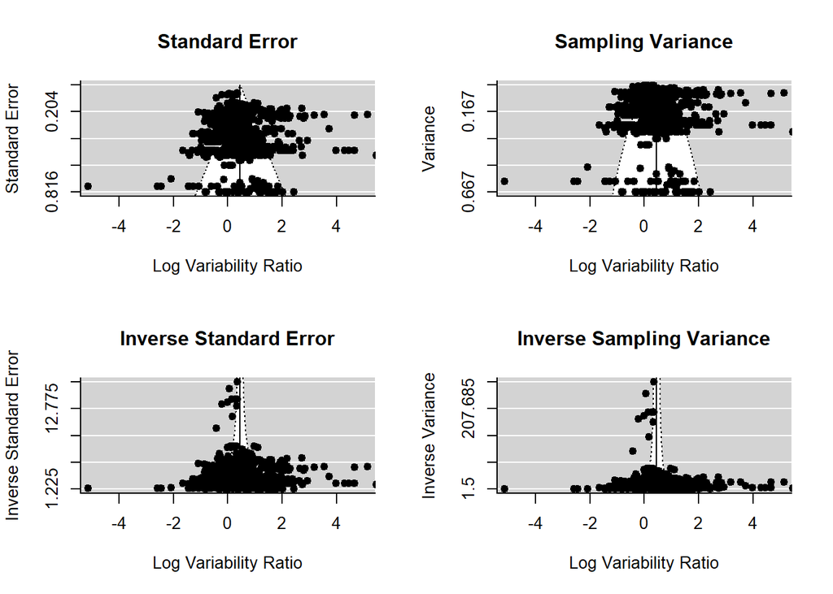

```r
res <- rma(yi = lnVR.es, vi = lnVR.sv, data = var.dif, method="FE")

## set up 2x2 array for plotting
par(mfrow=c(2,2))
## draw funnel plots
funnel(res, main="Standard Error", xlim = c(-5, 5))
funnel(res, yaxis="vi", main="Sampling Variance", xlim = c(-5, 5))
funnel(res, yaxis="seinv", main="Inverse Standard Error", xlim = c(-5, 5))
funnel(res, yaxis="vinv", main="Inverse Sampling Variance", xlim = c(-5, 5))
```

## Jugding novelty in phenotypic variabilities

```r
# load spLS files
dat <- read.csv("../data/dat.var.csv", head = TRUE)

#+++++++++++++++++++++++++++++++++++++++++++++++++++++++#
# Difference between larger species (spL) and hybrids
#+++++++++++++++++++++++++++++++++++++++++++++++++++++++#

for (i in c("spL")) { # identify type of hybrids
  for (cr in c("hybLS", "hybSL")) { # identify type of parentals
    assign(
      paste(cr, i, sep = "_"),
        escalc(
          measure = "VR",
          # N of hybrids
          n1i = dat[, paste("N", i, sep = ".")],
          # N of parentals
          n2i = dat[, paste("N", cr, sep = ".")],
          # Mean of hybrids
          m1i = dat[, paste("Mn", i, sep = ".")],
          # Mean of parentals
          m2i = dat[, paste("Mn", cr, sep = ".")],
          # SD of hybrids
          sd1i = dat[, paste("SD", i, sep = ".")],
          # SD of parentals
          sd2i = dat[, paste("SD", cr, sep = ".")],
          data = dat
          ) %>%
          select(ES.ID, yi, vi) %>%
          rename("lnVR.es" = "yi", "lnCVR.sv" = "vi") %>%
        mutate(
          # direction of transgressve segregation - greater than parent
          direction = "+",
          # SE for logistic distribution, for the weighted binomial regression
          # SE = pi/sqrt(3*(n_e + n_c))
          SE = pi/sqrt(3*(
            dat[, paste("N", i, sep = ".")] + dat[, paste("N", cr, sep = ".")]
          ))
        )
    )
  }
}

#+++++++++++++++++++++++++++++++++++++++++++++++++++++++#
# Difference between hybrids and smaller species (spS)
#+++++++++++++++++++++++++++++++++++++++++++++++++++++++#

for (i in c("hybLS", "hybSL")) { # identify type of hybrids
  for (cr in c("spS")) { # identify type of parentals
    assign(
      paste(i, cr, sep = "_"),
        escalc(
          measure = "VR",
          # N of hybrids
          n1i = dat[, paste("N", i, sep = ".")],
          # N of parentals
          n2i = dat[, paste("N", cr, sep = ".")],
          # Mean of hybrids
          m1i = dat[, paste("Mn", i, sep = ".")],
          # Mean of parentals
          m2i = dat[, paste("Mn", cr, sep = ".")],
          # SD of hybrids
          sd1i = dat[, paste("SD", i, sep = ".")],
          # SD of parentals
          sd2i = dat[, paste("SD", cr, sep = ".")],
          data = dat
          ) %>%
          select(ES.ID, yi, vi) %>%
          rename("lnVR.es" = "yi", "lnCVR.sv" = "vi") %>%
        mutate(
          # direction of transgressve segregation - smaller than parent
          direction = "-",
          # SE for logistic distribution, for the weighted binomial regression
          # SE = pi/sqrt(3*(n_e + n_c))
          SE = pi/sqrt(3*(
            dat[, paste("N", i, sep = ".")] + dat[, paste("N", cr, sep = ".")]
          ))
        )
    )
  }
}


#+++++++++++++++++++++++++++++++++++++++++++++++++++++++#
# Data output
#+++++++++++++++++++++++++++++++++++++++++++++++++++++++#

bind_rows(
  ## Difference with mother species ###
  bind_rows(hybLS_spL, hybSL_spS) %>%
    mutate(parental = "Mother"),
  ## Difference with father species ###
  bind_rows(hybLS_spS, hybSL_spL) %>%
    mutate(parental = "Father")
  ) %>%
  drop_na(lnVR.es) %>%
  left_join(., dat) %>%
  # Assign novel variability to 1, non-novel variability to 0 for each effect size
  mutate(Novelty = ifelse(lnVR.es < 0, 1, 0)) %>%
  ## Join with metadata ###
  left_join(
    .,
    read.xlsx(
      "../data/original.data.xlsx", sheet = "Species.level.moderators"
      )
    ) %>%
  mutate_at(vars(contains("divergence")), as.numeric) %>%
  mutate_at(vars(contains("divergence")), scale) %>%
  as.data.frame %>%
  select(-trait) %>%
  drop_na(Hetero.sex, trait.type, Genet.divergence) %>%
  # order taxon
  within(
    taxa <- ordered(
      taxa,
      levels = c("Neuroptera", "Coleoptera", "Diptera", "Lepidoptera", "Orthoptera", "Aves", "Rodentia", "Anura", "Cichliformes")
      )
    ) %>%
  mutate_if(is.character, as.factor) %>%
  # Insect or no
  mutate(
    insect = ifelse(taxa %in% c("Aves", "Rodentia", "Anura", "Cichliformes"), "no", "insect"),
  ) %>%
  write.csv("../data/lnVR.ES.Novelty.csv", row.names = F)
```

## Reload data & Prepare phylogenetic tree

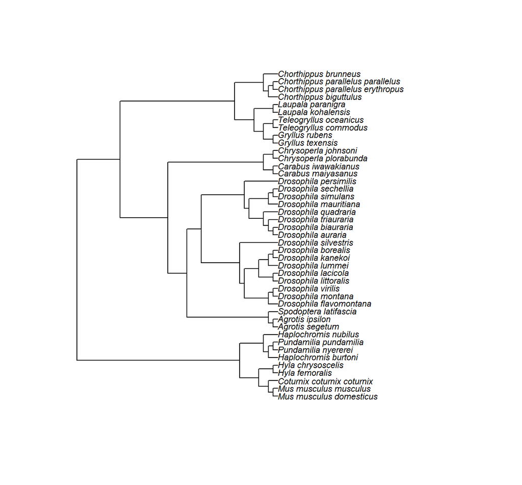

```r
# Load effect sizes
var.dif <- read.csv("../data/lnVR.ES.general.csv", head = TRUE)%>%
  # indicate dataset including novel variability
  mutate(data.type = "Alltraits")

# Observations with novel variability
All <- read.csv("../data/lnVR.ES.novelty.csv", head = TRUE) %>%
  filter(lnVR.es < 0) %>%
  distinct(ES.ID)

# Effect sizes with non-novel variability
Nonovel <- read.csv("../data/lnVR.ES.general.csv", head = TRUE) %>%
  filter(!ES.ID %in% unique(All$ES.ID)) %>%
  # indicate dataset without novel variability
  mutate(data.type = "Nonnoveltraits")

# combine dataset with/without novel variability
Novel.Nonnovel <- bind_rows(var.dif, Nonovel) %>%
  mutate(metaunit =  str_c(data.type, cross, sep = "_")) %>%
  # Use observations with both reciprocal crosses
  drop_na(contains("Mn"), contains("SD")) %>%
  # Insect or no
  mutate(
    insect = ifelse(taxa %in% c("Cichliformes", "Anura", "Aves", "Rodentia"), "no", "insect"),
  )

#+++++++++++++++++++++++++++++++#
# Phylogeny
#+++++++++++++++++++++++++++++++#

# # matching names from open tree taxonomy
# taxa <- tnrs_match_names(
#   names = levels(var.dif$spL.name) %>%
#     str_replace_all("_", " "),
#   context_name = "Animals"
#   )
#
# # Create tree
# tree <- tol_induced_subtree(ott_ids = taxa$ott_id)
# tree$tip.label %<>%
#   strip_ott_ids # remove OTT IDs from tip labels
# # randomly solve non-binary phylogeny
# set.seed(6)
# bin.tree <- multi2di(tree, random = T)
#
# # Fix names of tip labels
# bin.tree$tip.label %<>% str_replace_all("Dryophytes", "Hyla")
# # Indicate mismatch between tip labels & dataset species names
# setdiff(levels(as.factor(bin.tree$tip.label)), levels(var.dif$spL.name))
# setdiff(levels(var.dif$spL.name), levels(as.factor(bin.tree$tip.label)))
#
# write.tree(bin.tree, file= "../data/phylo.lnVR.tre")

# compute branch lengths of tree
phylo_branch <- read.tree(file = "../data/phylo.lnVR.tre") %>%
  compute.brlen(bin.tree, method = "Grafen", power = 1)

# saving phylogeneic matrix
phylo_cor <- vcv(phylo_branch, cor = T)

# Note one of the tips is called "Lates calcarifer (estimated)"
phylo_branch$node.label <- NULL

# Plot tree
plot.phylo(phylo_branch, cex = 0.7)
```

## Dominance in phenotypic variability (variance)

We compared midparent-value of phenotypic variability and hybrids’ phenotypic variability by calculating log ratio of phenotypic variability (lnVR) of midparent-value and hybrids to *spSS<sub>V</sub>*.

It’s sampling variance was substitute by that of *spLL<sub>V</sub>*

We statistically compared those effect sizes through the formal meta-regression by using `rma.mv` function of R package `metafor`

All meta-analytic models included following Random effects estimates:

- `Study.ID`: Primary studies. Denoted as **Study**
- `Cross.ID`: Parental strain used in the crossing. Discriminate intraspecific populations. Denoted as **crossed strain**
- `spL.name`: Phylogeny of parental species (*spLL<sub>M</sub>*). Denoted as **species with phylogeny**

```r
#+++++++++++++++++++++++++++++++++++++++++++#
# Calculate midparent
#+++++++++++++++++++++++++++++++++++++++++++#
midparent <- Novel.Nonnovel %>%
   mutate(
     lnVR.midparent.es =
       ifelse(
         cross == "spL",
         # log(Se/Sc)
         log((SD.spL + SD.spS)/2) - log(SD.spS) +
           # 1/2(Ne-1) - 1/2(Nc-1)
           1/(N.spL + N.spS -2) - 1/(2*N.spS - 2),
         lnVR.es
         )
     # Divide variance by 4 in spL whereas hybrids are constant
     ) %>%
   mutate_at("cross", as.factor) %>%
   within(levels(cross) <- c("hybLS", "hybSL", "midparent"))


#+++++++++++++++++++++++++++++++++++++++++++++++++++#
# Compare midparent and hybrids by meta-regresson
#+++++++++++++++++++++++++++++++++++++++++++++++++++#

for (tr in c("Alltraits", "Nonnoveltraits")) {
  for (taxon in c("alltaxon", "insect")) {

    # Filtering taxon (all taxon or insects)
    if (taxon == "alltaxon") {
      dat <- midparent %>%
        filter(data.type == tr)
    } else {
      dat <- midparent %>%
        filter(data.type == tr, insect == taxon)
    }

    #+++++++++++++++++++++++++++++++++++++++++++++++++++++++++++++++++#
    # Estimate meta-analytic mean of midparent of phenotypic variation
    #+++++++++++++++++++++++++++++++++++++++++++++++++++++++++++++++++#
    # midparent.compare <- rma.mv(
    #   yi = lnVR.midparent.es, V = lnVR.sv,
    #   data = dat,
    #   method = "REML",
    #   random = list(~1 | spL.name, ~1 | Study.ID, ~1 | Cross.ID, ~1 | ES.ID),
    #   R = list(spL.name = phylo_cor),
    #   mods = ~ relevel(cross, ref = "midparent")
    #   )
    # ## Save model ###
    # saveRDS(
    #   midparent.compare,
    #   file = paste("../Analysis/lnVR.midparent.compare", tr, taxon, "obj", sep = ".")
    #   )

    assign(
      paste("Dominance", tr, taxon, sep = "."),
      readRDS(paste("../Analysis/lnVR.midparent.compare", tr, taxon, "obj", sep = ".")) %>%
        get_reg() %>%
        # Show dataset name
        within(Dataset <- c(paste(tr, taxon), rep("", length(.$Estimate)-1))) %>%
        # Rename fixed effects
        within('Fixed effects' <- c("", "midparent (intrcpt)", "hybLS", "hybSL")) %>%
        # Difference of each cross from midparent in %
        mutate('Comparison with midparent' = c(
          rep("", 2),
          # Difference hybLS - midparent
          paste(
            round(
            100*(exp(midparent.compare$beta[1]+midparent.compare$beta[2])            -exp(midparent.compare$beta[1])), # hybrid LS
            2),
            "% larger"
            ),
              # beta[1] : midparent
              # beta[2] : hybLS
              # beta[3] : hybSL
          # Difference hybSL - midparent
          paste(
            round(
            100*(exp(midparent.compare$beta[1]+midparent.compare$beta[3])-exp(midparent.compare$beta[1])), # hybrid SL
            2),
            "% larger"
            )
          ))
      )

    #++++++++++++++++++++++++++++++++++++++++++++++#
    # Meta-analysis for midparent to plot band
    #++++++++++++++++++++++++++++++++++++++++++++++#
    # midparent.random <- rma.mv(
    #   yi = lnVR.midparent.es,
    #   V = lnVR.sv,
    #   data = dat %>%
    #     filter(cross == "midparent"),
    #   method = "REML",
    #   random = list(~1 | spL.name, ~1 | Study.ID, ~1 | Cross.ID, ~1 | ES.ID),
    #   R = list(spL.name = phylo_cor)
    #   )
    # ## Save model ###
    # saveRDS(
    #   midparent.random,
    #   file = paste("../Analysis/lnVR.midparent", tr, taxon, "obj", sep = ".")
    #   )

  }
}

bind_rows(
  Dominance.Alltraits.alltaxon, Dominance.Nonnoveltraits.alltaxon,
  Dominance.Alltraits.insect, Dominance.Nonnoveltraits.insect
  ) %>%
  kable("html", digits = 3, caption = "Meta-analyses results of full dataset and data subsets") %>%
  kable_styling("striped", position = "left") %>%
  scroll_box(width = "100%", height = "500px")
```

Meta-analyses results of full dataset and data subsets

Dataset

Fixed effects

Estimate

LowerCI

UpperCI

I2[total]

%I2[species with phylogeny]

%I2[study]

%I2[crossed strain]

%I2[residual]

P

significance

Comparison with midparent

Alltraits alltaxon

87.9%

1.2%

14.2%

0%

72.6%

midparent (intrcpt)

0.542

0.340

0.743

<0.001

hybLS

-0.049

-0.116

0.019

0.157

-21.11 % larger

hybSL

-0.083

-0.150

-0.016

0.015

-24.94 % larger

Nonnoveltraits alltaxon

82.1%

0%

23.9%

0%

58.2%

midparent (intrcpt)

0.756

0.536

0.976

<0.001

hybLS

-0.142

-0.232

-0.052

0.002

-21.11 % larger

hybSL

-0.140

-0.228

-0.051

0.002

-24.94 % larger

Alltraits insect

87.7%

0%

10%

0%

77.7%

midparent (intrcpt)

0.478

0.300

0.656

<0.001

hybLS

-0.063

-0.133

0.006

0.074

-21.11 % larger

hybSL

-0.107

-0.176

-0.038

0.002

-24.94 % larger

Nonnoveltraits insect

82.4%

0%

24.2%

0%

58.2%

midparent (intrcpt)

0.722

0.485

0.960

<0.001

hybLS

-0.167

-0.260

-0.074

<0.001

-21.11 % larger

hybSL

-0.179

-0.270

-0.088

<0.001

-24.94 % larger

## Crossing direction effect in phenotypic variability (variance)

We statistically compared lnVR from *spSS<sub>M</sub>* to the other crosses through the formal meta-regression by using `rma.mv` function of R package `metafor`.  
Here we asked if lnVR of *hybSL<sub>V</sub>* was smaller/larger than that of *hybLS<sub>V</sub>*. Smaller lnVR of *hybSL<sub>V</sub>* indicates maternal inheritance in phenotypic variability

```r
for (tr in c("Alltraits", "Nonnoveltraits")) {

  if (taxon == "alltaxon") {
    dat <- Novel.Nonnovel %>%
      filter(data.type == tr)
  } else {
    dat <- Novel.Nonnovel %>%
      filter(data.type == tr, insect == taxon)
  }

  for (taxon in c("alltaxon", "insect")) {
  #++++++++++++++++++++++++++++++++++++++++++++++#
  # phylogenetic random regresson (ANOVA)
  #++++++++++++++++++++++++++++++++++++++++++++++#
  # phyl.random.hybLS <- rma.mv(
  #   yi = lnVR.es, V = lnVR.sv,
  #   data = dat, method = "REML",
  #   random = list(~1 | spL.name, ~1 | Study.ID, ~1 | Cross.ID, ~1 | ES.ID),
  #   R = list(spL.name = phylo_cor),
  #   mods = ~ cross
  #   )
  # # Save model ###
  # saveRDS(
  #   phyl.random.hybLS,
  #   file = paste("../Analysis/lnVR.compare.from.hybLS", tr, taxon, "obj", sep = ".")
  #   )

    phyl.random.hybLS <- readRDS(
      paste("../Analysis/lnVR.compare.from.hybLS", tr, taxon, "obj", sep = ".")
      )

    assign(
      paste("Reciprocal", tr, taxon, sep = "."),
      phyl.random.hybLS %>%
        get_reg() %>%
        # Show dataset name
        within(Dataset <- c(paste(tr, taxon), rep("", length(.$Estimate)-1))) %>%
        # Rename fixed effects
        within('Fixed effects' <- c("", "hybLS (intrcpt)", "hybSL", "spLL")) %>%
        # Difference of each cross from midparent in %
        mutate('Comparison with hybridLS' = c(
          rep("", 2),
          paste(
            round(
              (exp(phyl.random.hybLS$beta[1]+phyl.random.hybLS$beta[2]) -
                 exp(phyl.random.hybLS$beta[1])
               )*100,
              2),
            "% larger"
            ),
          ""
          )
        )
      )
  }
}

bind_rows(
  Reciprocal.Alltraits.alltaxon, Reciprocal.Nonnoveltraits.alltaxon,
  Reciprocal.Alltraits.insect, Reciprocal.Nonnoveltraits.insect
  ) %>%
  kable("html", digits = 3, caption = "Meta-analyses results of full dataset and data subsets") %>%
  kable_styling("striped", position = "left") %>%
  scroll_box(width = "100%", height = "500px")
```

Meta-analyses results of full dataset and data subsets

Dataset

Fixed effects

Estimate

LowerCI

UpperCI

I2[total]

%I2[species with phylogeny]

%I2[study]

%I2[crossed strain]

%I2[residual]

P

significance

Comparison with hybridLS

Alltraits alltaxon

89.6%

0%

14.2%

0%

75.3%

hybLS (intrcpt)

0.498

0.301

0.696

<0.001

hybSL

-0.032

-0.104

0.039

0.378

-5.21 % larger

spLL

0.280

0.212

0.347

<0.001

Nonnoveltraits alltaxon

85.8%

0%

23.4%

0%

62.4%

hybLS (intrcpt)

0.641

0.392

0.890

<0.001

hybSL

0.007

-0.088

0.101

0.893

1.24 % larger

spLL

0.416

0.326

0.506

<0.001

Alltraits insect

89.4%

0%

9.6%

0%

79.8%

hybLS (intrcpt)

0.425

0.233

0.618

<0.001

hybSL

-0.042

-0.116

0.032

0.261

-6.35 % larger

spLL

0.293

0.223

0.363

<0.001

Nonnoveltraits insect

86.1%

0%

23.6%

0%

62.5%

hybLS (intrcpt)

0.582

0.312

0.852

<0.001

hybSL

-0.009

-0.107

0.089

0.857

-1.6 % larger

spLL

0.438

0.345

0.531

<0.001

# References

Alibert, P., and J.-C. Auffray. 2003. Genomic coadaptation, outbreeding depression and developmental instability. Pp. 116–134 *in* M. Polak, ed. Developmental instability: Causes and consequences. Oxford University Press, New York.

Bridle, J. R., C. I. Saldamando, W. Koning, and R. K. Butlin. 2006. Assortative preferences and discrimination by females against hybrid male song in the grasshoppers Chorthippus brunneus and <i>Chorthippus jacobsi</i> (Orthoptera: Acrididae). Journal of Evolutionary Biology 19:1248–1256.

Cockett, N. E., S. P. Jackson, T. L. Shay, F. Farnir, S. Berghmans, G. D. Snowder, D. M. Nielsen, and M. Georges. 1996. Polar overdominance at the ovine callipyge locus. Science 273:236–238.

Doherty, J. A., and H. C. Gerhardt. 1984. Acoustic communication in hybrid treefrogs: sound production by males and selective phonotaxis by females. Journal of Comparative Physiology A 154:319–330.

Edmands, S. 1999. Heterosis and outbreeding depression in interpopulation crosses spanning a wide range of divergence. Evolution 53:1757.

Gottsberger, B., and F. Mayer. 2019. Dominance effects strengthen premating hybridization barriers between sympatric species of grasshoppers (Acrididae, Orthoptera). Journal of Evolutionary Biology 921–930.

Haldane, J. B. S. 1922. Sex ratio and unisexual sterility in hybrid animals. Journal of Genetics 12:101–109.

Hochkirch, A., and I. Lemke. 2011. Asymmetric mate choice, hybridization, and hybrid fitness in two sympatric grasshopper species. Behavioral Ecology and Sociobiology 65:1637–1645.

Hoffmann, A. A., J. Merilä, and T. N. Kristensen. 2016. Heritability and evolvability of fitness and nonfitness traits: Lessons from livestock. Evolution; international journal of organic evolution 70:1770–1779.

Isoherranen, E., J. Aspi, and A. Hoikkala. 1999. Inheritance of species differences in female receptivity and song requirement between Drosophila virilis and D. montana. Hereditas 131:203–209.

Lamkey, K. R., and J. W. Edwards. 1999. Quantitative genetics of heterosis. Pp. 31–48 *in* J. G. Coors and S. Pandey, eds. The genetics and exploitation of heterosis in crops. CIMMYT, Mexico City.

Lerner, I. M. 1954. Genetic homeostasis. Oliver; Boyd, Edinburgh, Scotland.

Nakagawa, S., R. Poulin, K. Mengersen, K. Reinhold, L. Engqvist, M. Lagisz, and A. M. Senior. 2015. Meta-analysis of variation: Ecological and evolutionary applications and beyond. Methods in Ecology and Evolution 6:143–152.

Rieseberg, L. H., M. A. Archer, and R. K. Wayne. 1999. Transgressive segregation, adaptation and speciation. Heredity 83:363–372.

Ritchie, M. G. 2000. The inheritance of female preference functions in a mate recognition system. Proceedings of the Royal Society B: Biological Sciences 267:327–332.

Schilthuizen, M., M. C. W. G. Giesbers, and L. W. Beukeboom. 2011. Haldane’s rule in the 21st century. Heredity 107:95–102.

Shaw, K. L. 2000. Interspecific genetics of mate recognition: Inheritance of female acoustic preference in Hawaiian crickets. Evolution 54:1303–1312. Department of Organismic; Evolutionary Biology, Harvard University, Cambridge, MA 02138, United States.

Thompson, K. A., M. Urquhart-Cronish, K. D. Whitney, L. H. Rieseberg, and D. Schluter. 2021. Patterns, Predictors, and Consequences of Dominance in Hybrids. The American Naturalist 197:E000–E000.